# Exploring lakefish data

Emma Sofie Skarstein and Lyder Iversen

November 2019

## About the data

We will be looking at observations of freshwater fish in Norwegian lakes. Our observations are obtained from GBIF (more formal referencing of data somehow?), by first downloading all ray-finned fish (Actinopterygii) observations registered in Norway, and then filtering these based on the following steps:

1. Filter out species not in list of Norwegian freshwater fish, [as described by SNL](https://snl.no/ferskvannsfisk_i_Norge)
2. Match all species to closest lake, and remove observation further than 10 meters from the closest lake
3. Remove all observations with no time variable.
4. Select 12 most prevalent species.

The list of fish we downloaded can be seen below. We excluded fish that spawn in salt water, so some species that may be observed in lakes, such as eel (*Anguilla anguilla*) and European flounder (*Platichthys flesus*), have been excluded from our analysis as a result of this.

[output not shown]

## Preliminary insights

To begin with, for the sake of us non-biologists, here are the latin, English and Norwegian names of the twelve included species.

- Phoxinus phoxinus - Minnow - Ørekyte
- Rutilus rutilus - Roach - Mort
- Salmo trutta - Trout - Ørret
- Esox lucius - Pike - Gjedde
- Salmo salar - Salmon - Laks
- Gasterosteus aculeatus - Three-spined stickleback - Trepigget stingsild
- Lota lota - Burbot - Lake
- Perca fluviatilis - Perch - Abbor
- Salvelinus alpinus - Arctic char - Røye
- Coregonus lavaretus - Lavaret - Sik
- Coregonus albula - European cisco - Lagesild
- Salvelinus fontinalis - Brook char - Bekkerøye

Let us take a look at the number of observations of each species.

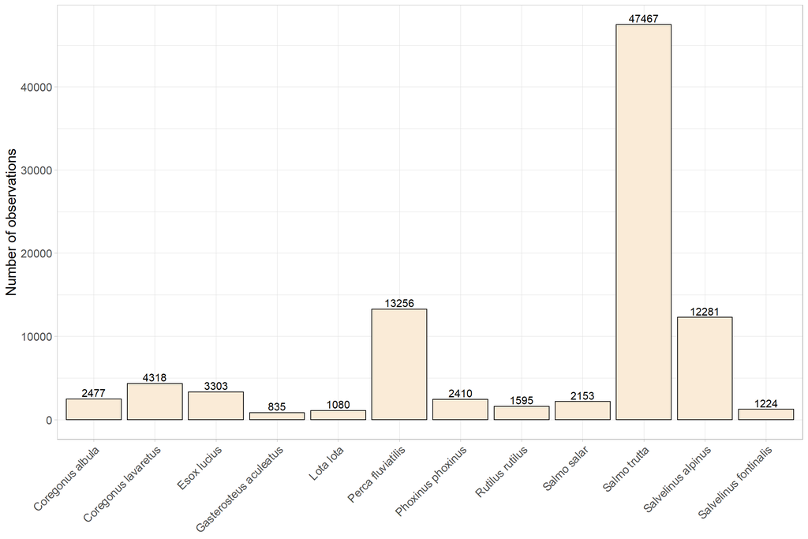

Here we see that *Salmo trutta* (trout) outranks the other species by quite a bit, although *Perca fluviatilis* (European perch) and *Salvelinus alpinus* (arctic char) are also quite prevalent.

It is also interesting to take a look at when the observations were made. An important characteristic of our data is the fact that the observations appear at very irregular times, there are some years when there seem to be large studies of many lakes, while other years there are only a few single observations. The earliest observation is made in 1877, but the first decades are mostly just observations made in single lakes and are not very numerous. We look at the observation counts for the years after 1970, which is when observations really start increasing.

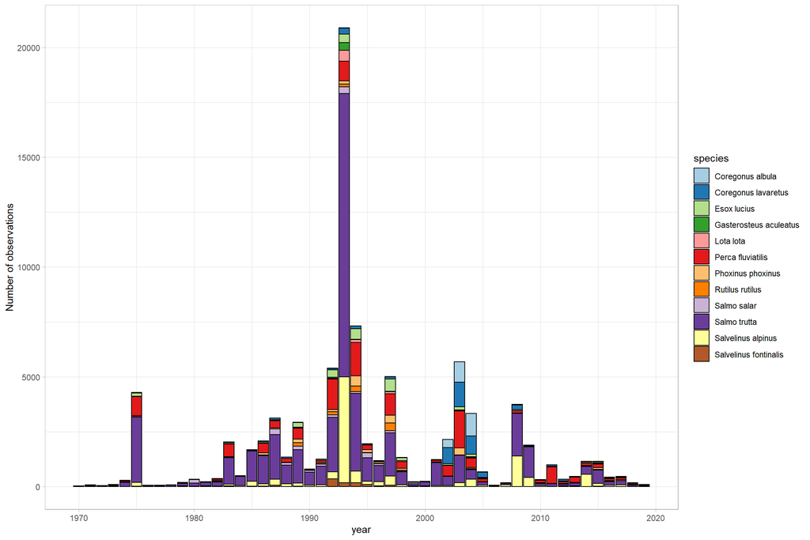

Lastly, we also take a look at where the observations are made.

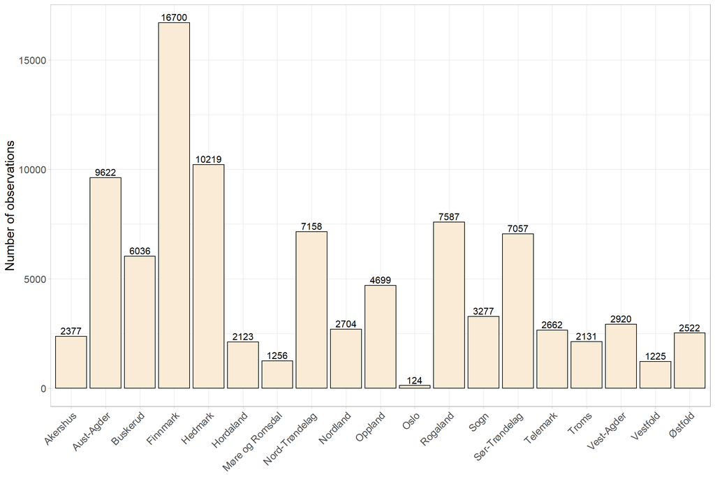

## Plotting data on the map

First, let us look at all the observations on a map of Norway.

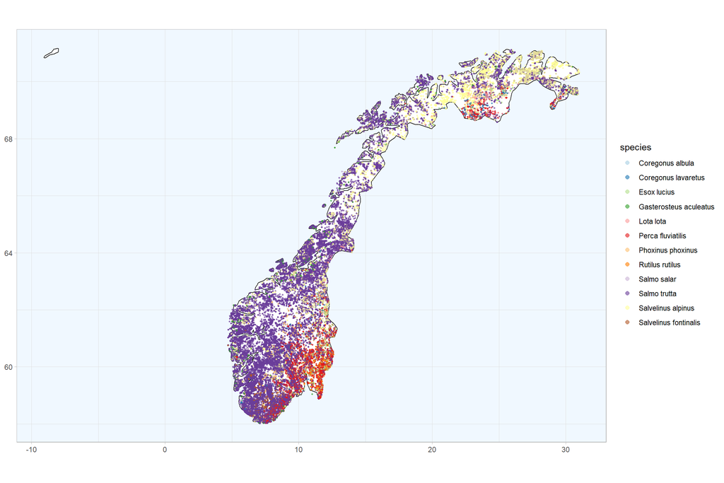

So, we can definitely see *something* here, but it is a bit of a mess. We have added some transparency to the points, but they are still very much on top of each other, so this does not necessarily convey what we want it to. Let us facet it into one map per species to tidy it up a bit.

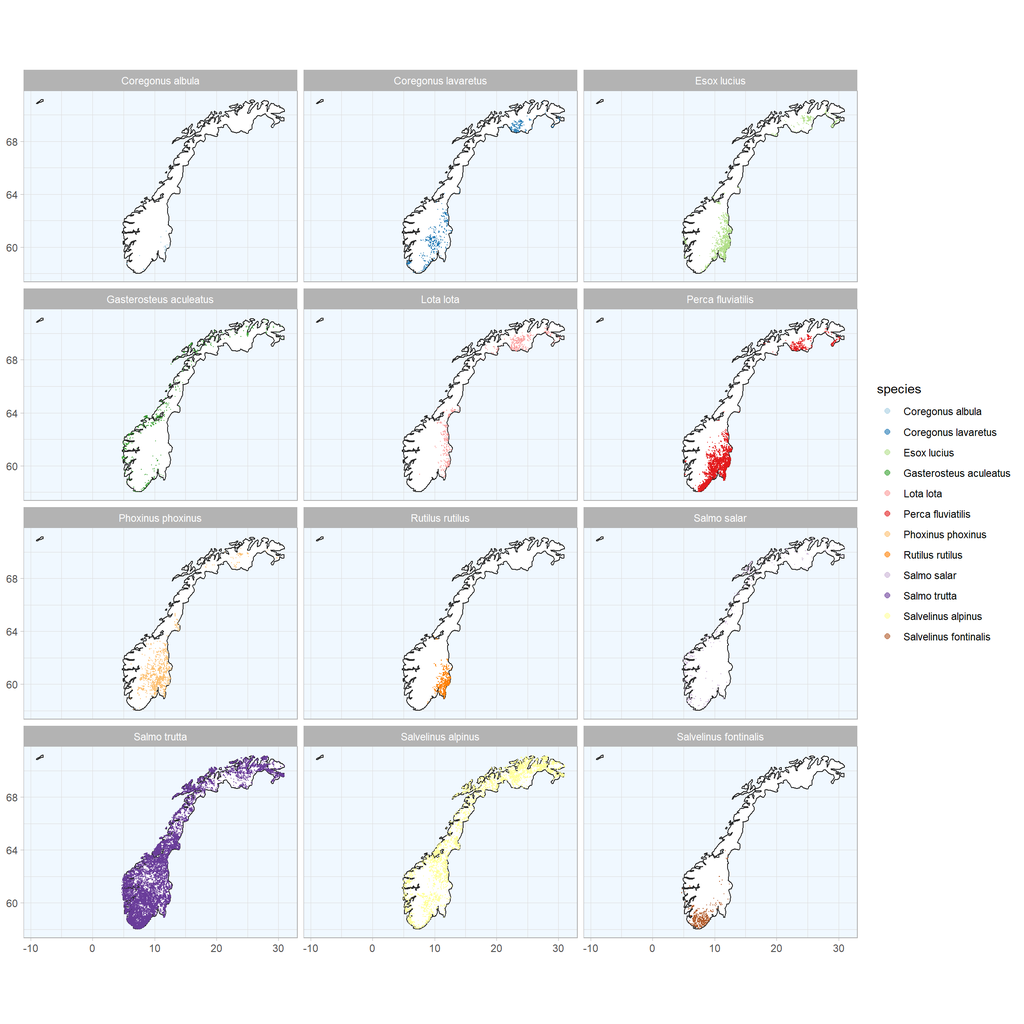

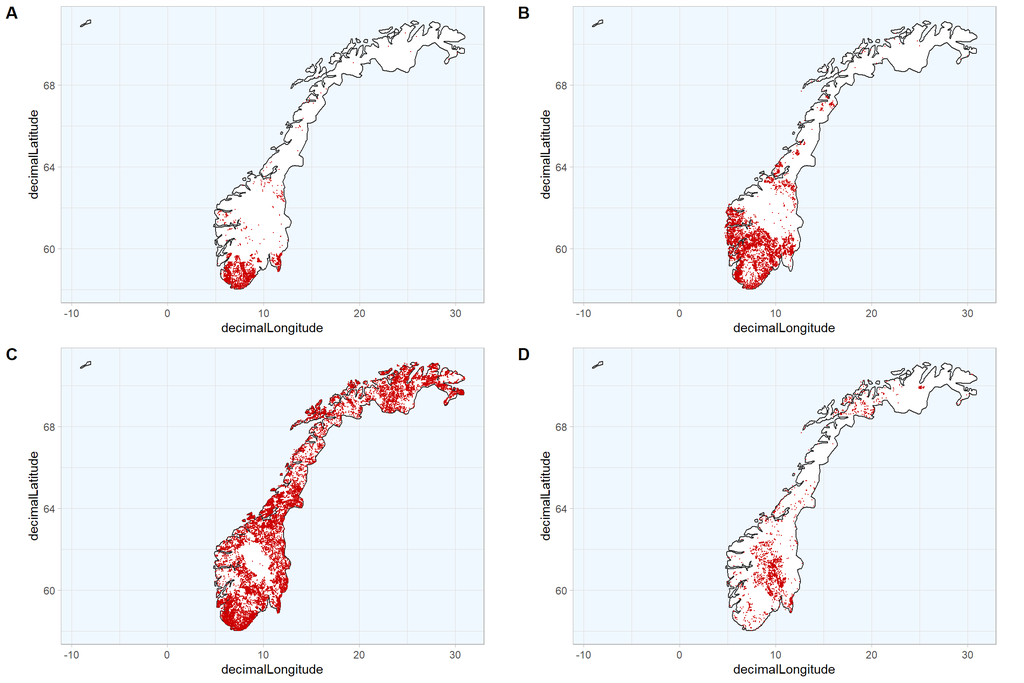

By counting the number of unique species per lake we can find the species richness per lake.

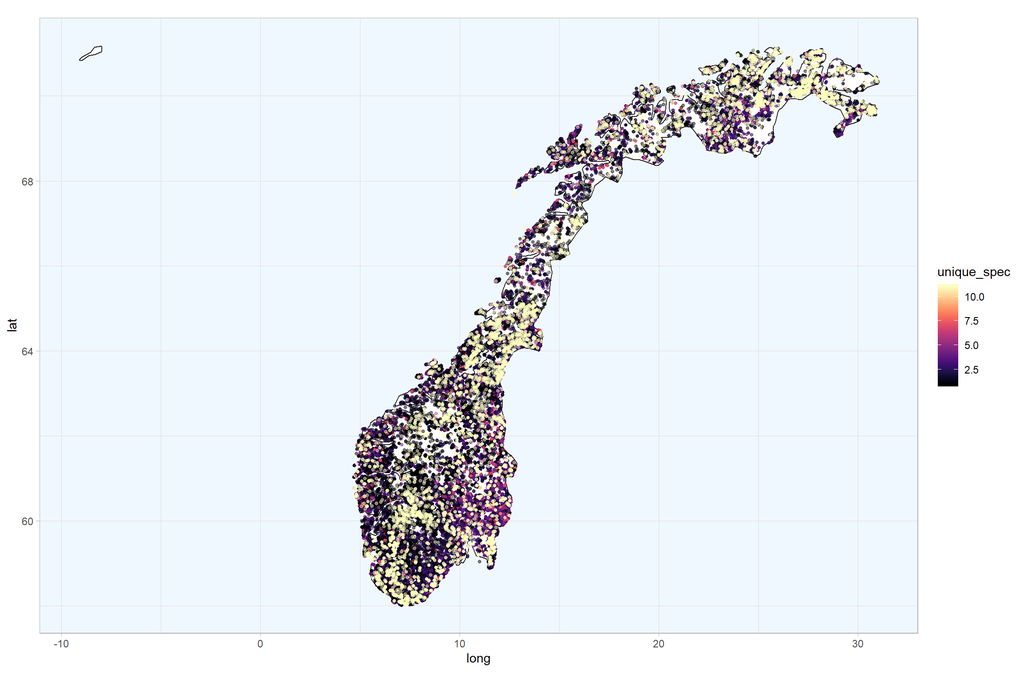

```
## # A tibble: 6 x 2
##   waterBody              unique_spec
##   <chr>                        <int>
## 1 "\u001aámmájohjávrrit"           1
## 2 "\u001aazajávri"                 1
## 3 "\u001aearoaljávrrit"            1
## 4 "\u001aearretjávri"              1
## 5 "\u001aearretláddot"             1
## 6 "\u001auometjávri"               1
```

Next plots:

- Would it be interesting to zoom in somewhere?